# 모의고사1

### 1.2.2) 향상도 상위 30개, csv

```python
df30 = rules_1.sort_values(by='lift', ascending=False)[:30].reset_index()
df30
```

|  | index | lhs | rhs | Support | Confidence | lift |
| --- | --- | --- | --- | --- | --- | --- |
| 0 | 393 | [16, 26, 31] | [43, 36] | 0.002328 | 1.0 | 78.090909 |
| 1 | 390 | [26, 21, 14] | [18, 15] | 0.002328 | 1.0 | 71.583333 |
| 2 | 387 | [26, 11, 36] | [17, 21] | 0.002328 | 1.0 | 61.357143 |
| 3 | 386 | [10, 34, 22] | [36, 44] | 0.002328 | 1.0 | 61.357143 |
| 4 | 384 | [18, 45, 6] | [38, 31] | 0.002328 | 1.0 | 57.266667 |
| 5 | 385 | [31, 22, 7] | [24, 34] | 0.002328 | 1.0 | 57.266667 |
| 6 | 388 | [12, 20, 15] | [24, 30] | 0.002328 | 1.0 | 57.266667 |
| 7 | 391 | [40, 14, 30] | [27, 31] | 0.002328 | 1.0 | 53.687500 |
| 8 | 389 | [40, 13, 14] | [26, 43] | 0.002328 | 1.0 | 45.210526 |
| 9 | 392 | [19, 44, 21] | [34, 15] | 0.002328 | 1.0 | 40.904762 |
| 10 | 321 | [17, 18, 31] | [32] | 0.002328 | 1.0 | 8.855670 |
| 11 | 210 | [10, 18, 31] | [32] | 0.002328 | 1.0 | 8.855670 |
| 12 | 84 | [24, 3, 45] | [32] | 0.002328 | 1.0 | 8.855670 |
| 13 | 292 | [33, 29, 14] | [32] | 0.002328 | 1.0 | 8.855670 |
| 14 | 80 | [40, 18, 3] | [32] | 0.002328 | 1.0 | 8.855670 |
| 15 | 76 | [3, 13, 31] | [32] | 0.002328 | 1.0 | 8.855670 |
| 16 | 74 | [18, 3, 12] | [32] | 0.002328 | 1.0 | 8.855670 |
| 17 | 295 | [42, 36, 14] | [32] | 0.002328 | 1.0 | 8.855670 |
| 18 | 335 | [18, 21, 39] | [23] | 0.002328 | 1.0 | 8.676768 |
| 19 | 362 | [25, 42, 38] | [23] | 0.002328 | 1.0 | 8.676768 |
| 20 | 300 | [20, 39, 15] | [23] | 0.002328 | 1.0 | 8.676768 |
| 21 | 302 | [20, 44, 15] | [23] | 0.002328 | 1.0 | 8.676768 |
| 22 | 280 | [18, 20, 14] | [23] | 0.002328 | 1.0 | 8.676768 |
| 23 | 182 | [8, 13, 31] | [23] | 0.002328 | 1.0 | 8.676768 |
| 24 | 8 | [1, 12, 7] | [23] | 0.002328 | 1.0 | 8.676768 |
| 25 | 363 | [26, 44, 39] | [23] | 0.002328 | 1.0 | 8.676768 |
| 26 | 303 | [24, 20, 15] | [30] | 0.002328 | 1.0 | 8.180952 |
| 27 | 154 | [9, 23, 7] | [28] | 0.002328 | 1.0 | 8.180952 |
| 28 | 260 | [32, 13, 14] | [41] | 0.002328 | 1.0 | 8.180952 |
| 29 | 57 | [10, 3, 6] | [30] | 0.002328 | 1.0 | 8.180952 |

```python
# os.makedirs('./output')
df30.to_csv('./output/모의고사1(lotto).csv')
os.listdir('./output')
```

```
['bugs.txt', '모의고사1(lotto).csv']
```

### 해석

해당 조건으로 총 394개의 연관규칙이 생성되었다.

### Q3) 생성된 연관규칙 'rules_1'에 대한 정보를 해석하고, Q1)을 통해 확인했을 때

### 가장 많이 추첨된 번호가 우측항에 존재하는 규칙들만을 'rules_most_freq'라는 변수에

### 저장하시오. 그리고 해당 규칙들을 해석하여 인사이트를 도출한 후 서술하시오.

```
- 1.3.1) rules_1 해석
- 1.3.2) rules_most_freq 도출, 해석, 인사이트
```

### 1.3.1) rules_1 해석

```python
display( rules_1 )
```

|  | lhs | rhs | Support | Confidence | lift |
| --- | --- | --- | --- | --- | --- |
| 0 | [1, 3, 43] | [12] | 0.002328 | 1.0 | 6.983740 |
| 1 | [1, 3, 15] | [25] | 0.002328 | 1.0 | 7.738739 |
| 2 | [25, 3, 20] | [1] | 0.002328 | 1.0 | 7.040984 |
| 3 | [1, 3, 29] | [37] | 0.002328 | 1.0 | 7.341880 |
| 4 | [1, 11, 5] | [18] | 0.002328 | 1.0 | 7.099174 |
| ... | ... | ... | ... | ... | ... |
| 389 | [40, 13, 14] | [26, 43] | 0.002328 | 1.0 | 45.210526 |
| 390 | [26, 21, 14] | [18, 15] | 0.002328 | 1.0 | 71.583333 |
| 391 | [40, 14, 30] | [27, 31] | 0.002328 | 1.0 | 53.687500 |
| 392 | [19, 44, 21] | [34, 15] | 0.002328 | 1.0 | 40.904762 |
| 393 | [16, 26, 31] | [43, 36] | 0.002328 | 1.0 | 78.090909 |

394 rows × 5 columns

```python
rules_1.describe()
```

|  | Support | Confidence | lift |
| --- | --- | --- | --- |
| count | 394.000000 | 394.0 | 394.000000 |
| mean | 0.002361 | 1.0 | 8.684778 |
| std | 0.000192 | 0.0 | 8.219259 |
| min | 0.002328 | 1.0 | 6.410448 |
| 25% | 0.002328 | 1.0 | 7.040984 |
| 50% | 0.002328 | 1.0 | 7.279661 |
| 75% | 0.002328 | 1.0 | 7.669643 |
| max | 0.003492 | 1.0 | 78.090909 |

### 해석

로또 당첨번호를 의미하는 트랜잭션 데이터의 개수는 859개이며,  
이중 394개의 연관규칙이 생성되었고, 대부분 3개의 로또번호로 구성되었다.  
향상도 최대값은 78로 꽤 높게 나타났으며, 추첨번호들의 교집합 확률을  
의미하는 지지도의 평균은 0.002361로 나타났다.

### 1.3.2) rules_most_freq 도출, 해석, 인사이트

```
- q1에서 가장많이 도출된 번호: 34
```

```python
rules_most_freq = rules_1[rules_1['rhs'].isin(['[34]'])].reset_index()
rules_most_freq = rules_most_freq.drop(['index'], axis=1)
print(rules_most_freq.shape)
rules_most_freq
```

```
(16, 5)
```

|  | lhs | rhs | Support | Confidence | lift |
| --- | --- | --- | --- | --- | --- |
| 0 | [1, 13, 5] | [34] | 0.002328 | 1.0 | 6.410448 |
| 1 | [2, 4, 31] | [34] | 0.003492 | 1.0 | 6.410448 |
| 2 | [2, 21, 15] | [34] | 0.002328 | 1.0 | 6.410448 |
| 3 | [2, 28, 15] | [34] | 0.002328 | 1.0 | 6.410448 |
| 4 | [13, 29, 5] | [34] | 0.002328 | 1.0 | 6.410448 |
| 5 | [17, 29, 5] | [34] | 0.002328 | 1.0 | 6.410448 |
| 6 | [31, 22, 7] | [34] | 0.002328 | 1.0 | 6.410448 |
| 7 | [24, 31, 7] | [34] | 0.002328 | 1.0 | 6.410448 |
| 8 | [12, 37, 36] | [34] | 0.002328 | 1.0 | 6.410448 |
| 9 | [25, 44, 14] | [34] | 0.002328 | 1.0 | 6.410448 |
| 10 | [41, 19, 15] | [34] | 0.002328 | 1.0 | 6.410448 |
| 11 | [32, 17, 33] | [34] | 0.003492 | 1.0 | 6.410448 |
| 12 | [17, 42, 45] | [34] | 0.002328 | 1.0 | 6.410448 |
| 13 | [19, 44, 21] | [34] | 0.002328 | 1.0 | 6.410448 |
| 14 | [24, 22, 31] | [34] | 0.002328 | 1.0 | 6.410448 |
| 15 | [42, 45, 23] | [34] | 0.002328 | 1.0 | 6.410448 |

```python
rules_most_freq.reset_index()
```

|  | index | lhs | rhs | Support | Confidence | lift |
| --- | --- | --- | --- | --- | --- | --- |
| 0 | 0 | [1, 13, 5] | [34] | 0.002328 | 1.0 | 6.410448 |
| 1 | 1 | [2, 4, 31] | [34] | 0.003492 | 1.0 | 6.410448 |
| 2 | 2 | [2, 21, 15] | [34] | 0.002328 | 1.0 | 6.410448 |
| 3 | 3 | [2, 28, 15] | [34] | 0.002328 | 1.0 | 6.410448 |
| 4 | 4 | [13, 29, 5] | [34] | 0.002328 | 1.0 | 6.410448 |
| 5 | 5 | [17, 29, 5] | [34] | 0.002328 | 1.0 | 6.410448 |
| 6 | 6 | [31, 22, 7] | [34] | 0.002328 | 1.0 | 6.410448 |
| 7 | 7 | [24, 31, 7] | [34] | 0.002328 | 1.0 | 6.410448 |
| 8 | 8 | [12, 37, 36] | [34] | 0.002328 | 1.0 | 6.410448 |
| 9 | 9 | [25, 44, 14] | [34] | 0.002328 | 1.0 | 6.410448 |
| 10 | 10 | [41, 19, 15] | [34] | 0.002328 | 1.0 | 6.410448 |
| 11 | 11 | [32, 17, 33] | [34] | 0.003492 | 1.0 | 6.410448 |
| 12 | 12 | [17, 42, 45] | [34] | 0.002328 | 1.0 | 6.410448 |
| 13 | 13 | [19, 44, 21] | [34] | 0.002328 | 1.0 | 6.410448 |
| 14 | 14 | [24, 22, 31] | [34] | 0.002328 | 1.0 | 6.410448 |
| 15 | 15 | [42, 45, 23] | [34] | 0.002328 | 1.0 | 6.410448 |

### 해석

하지만 이러한 규칙들은 로또번호가 추첨되는 순서를 고려하지 않고  
단순히 조합에 대한 확률만을 고려한 규칙이므로,  
향상도가 높은 숫자들의 조합이 로또 추첨번호가 될 가능성이 높은 것이 아니다.

# 2. 통계분석 (사용 데이터: FIFA)

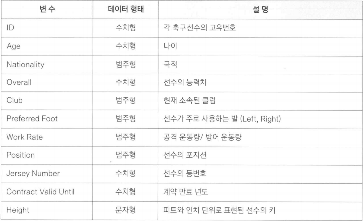

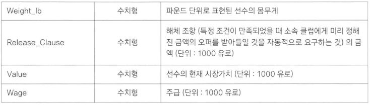

### 1) FIFA데이터에서 각 선수의 키는 Heghit변수에 피트와 인치로 입력되어 있습니다.

### 이를 cm로 변환하여 새로운 변수 Height_cm을 생성하시오.

### “ ' ” 앞의 숫자는 피트이며, “ ' ” 뒤의 숫자는 인치, 1피트 = 30cm, 1인치 = 2.5cm)

```python
df = pd.read_csv('./dataset/FIFA.csv', encoding = 'cp949')
df
```

|  | ID | Name | Age | Nationality | Overall | Club | Preferred_Foot | Work_Rate | Position | Jersey_Number | Contract_Valid_Until | Height | Weight_lb | Release_Clause | Value | Wage |
| --- | --- | --- | --- | --- | --- | --- | --- | --- | --- | --- | --- | --- | --- | --- | --- | --- |
| 0 | 158023 | L. Messi | 31 | Argentina | 94 | FC Barcelona | Left | Medium/ Medium | RF | 10 | 2021 | 5'7 | 159 | 226500 | 110500 | 565 |
| 1 | 20801 | Cristiano Ronaldo | 33 | Portugal | 94 | Juventus | Right | High/ Low | ST | 7 | 2022 | 6'2 | 183 | 127100 | 77000 | 405 |
| 2 | 190871 | Neymar Jr | 26 | Brazil | 92 | Paris Saint-Germain | Right | High/ Medium | LW | 10 | 2022 | 5'9 | 150 | 228100 | 118500 | 290 |
| 3 | 193080 | De Gea | 27 | Spain | 91 | Manchester United | Right | Medium/ Medium | GK | 1 | 2020 | 6'4 | 168 | 138600 | 72000 | 260 |
| 4 | 192985 | K. De Bruyne | 27 | Belgium | 91 | Manchester City | Right | High/ High | RCM | 7 | 2023 | 5'11 | 154 | 196400 | 102000 | 355 |
| ... | ... | ... | ... | ... | ... | ... | ... | ... | ... | ... | ... | ... | ... | ... | ... | ... |
| 16637 | 238813 | J. Lundstram | 19 | England | 47 | Crewe Alexandra | Right | Medium/ Medium | CM | 22 | 2019 | 5'9 | 134 | 143 | 60 | 1 |
| 16638 | 243165 | N. Christoffersson | 19 | Sweden | 47 | Trelleborgs FF | Right | Medium/ Medium | ST | 21 | 2020 | 6'3 | 170 | 113 | 60 | 1 |
| 16639 | 241638 | B. Worman | 16 | England | 47 | Cambridge United | Right | Medium/ Medium | ST | 33 | 2021 | 5'8 | 148 | 165 | 60 | 1 |
| 16640 | 246268 | D. Walker-Rice | 17 | England | 47 | Tranmere Rovers | Right | Medium/ Medium | RW | 34 | 2019 | 5'10 | 154 | 143 | 60 | 1 |
| 16641 | 246269 | G. Nugent | 16 | England | 46 | Tranmere Rovers | Right | Medium/ Medium | CM | 33 | 2019 | 5'10 | 176 | 165 | 60 | 1 |

16642 rows × 16 columns

```python
df.info() # 16 columns
```

```
<class 'pandas.core.frame.DataFrame'>
RangeIndex: 16642 entries, 0 to 16641
Data columns (total 16 columns):
ID                      16642 non-null int64
Name                    16642 non-null object
Age                     16642 non-null int64
Nationality             16642 non-null object
Overall                 16642 non-null int64
Club                    16642 non-null object
Preferred_Foot          16642 non-null object
Work_Rate               16642 non-null object
Position                16642 non-null object
Jersey_Number           16642 non-null int64
Contract_Valid_Until    16642 non-null int64
Height                  16642 non-null object
Weight_lb               16642 non-null int64
Release_Clause          16642 non-null int64
Value                   16642 non-null int64
Wage                    16642 non-null int64
dtypes: int64(9), object(7)
memory usage: 2.0+ MB
```

```python
df.isna().sum().sum()
```

```
0
```

```python
df['Height']
```

```
0         5'7
1         6'2
2         5'9
3         6'4
4        5'11
         ...
16637     5'9
16638     6'3
16639     5'8
16640    5'10
16641    5'10
Name: Height, Length: 16642, dtype: object
```

```python
buf_list = df['Height'].str.split("'")
cm = []
for buf in buf_list:
    cm.append( float(buf[0])*30 + float(buf[1])*2.5)
```

```python
df['Height_cm'] = cm
df['Height_cm'] = df['Height_cm'].round(4)
df[['Height', 'Height_cm']]
```

|  | Height | Height_cm |
| --- | --- | --- |
| 0 | 5'7 | 167.5 |
| 1 | 6'2 | 185.0 |
| 2 | 5'9 | 172.5 |
| 3 | 6'4 | 190.0 |
| 4 | 5'11 | 177.5 |
| ... | ... | ... |
| 16637 | 5'9 | 172.5 |
| 16638 | 6'3 | 187.5 |
| 16639 | 5'8 | 170.0 |
| 16640 | 5'10 | 175.0 |
| 16641 | 5'10 | 175.0 |

16642 rows × 2 columns

```python
df.info()  # 17 columns
```

```
<class 'pandas.core.frame.DataFrame'>
RangeIndex: 16642 entries, 0 to 16641
Data columns (total 17 columns):
ID                      16642 non-null int64
Name                    16642 non-null object
Age                     16642 non-null int64
Nationality             16642 non-null object
Overall                 16642 non-null int64
Club                    16642 non-null object
Preferred_Foot          16642 non-null object
Work_Rate               16642 non-null object
Position                16642 non-null object
Jersey_Number           16642 non-null int64
Contract_Valid_Until    16642 non-null int64
Height                  16642 non-null object
Weight_lb               16642 non-null int64
Release_Clause          16642 non-null int64
Value                   16642 non-null int64
Wage                    16642 non-null int64
Height_cm               16642 non-null float64
dtypes: float64(1), int64(9), object(7)
memory usage: 2.2+ MB
```

### Q2) 포지션을 의미하는 Position변수를 아래 표를 참고하여 “Forward”, “Midfielder”,

### “Defender”, “GoalKeeper”로 재범주화하고, factor형으로 변환하여 Position_Class

### 라는 변수를 생성하고 저장하시오.

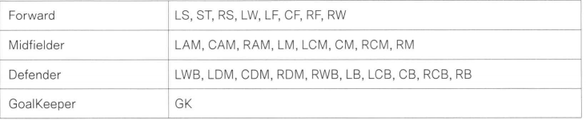

```python
df
```

|  | ID | Name | Age | Nationality | Overall | Club | Preferred_Foot | Work_Rate | Position | Jersey_Number | Contract_Valid_Until | Height | Weight_lb | Release_Clause | Value | Wage | Height_cm |
| --- | --- | --- | --- | --- | --- | --- | --- | --- | --- | --- | --- | --- | --- | --- | --- | --- | --- |
| 0 | 158023 | L. Messi | 31 | Argentina | 94 | FC Barcelona | Left | Medium/ Medium | RF | 10 | 2021 | 5'7 | 159 | 226500 | 110500 | 565 | 167.5 |
| 1 | 20801 | Cristiano Ronaldo | 33 | Portugal | 94 | Juventus | Right | High/ Low | ST | 7 | 2022 | 6'2 | 183 | 127100 | 77000 | 405 | 185.0 |
| 2 | 190871 | Neymar Jr | 26 | Brazil | 92 | Paris Saint-Germain | Right | High/ Medium | LW | 10 | 2022 | 5'9 | 150 | 228100 | 118500 | 290 | 172.5 |
| 3 | 193080 | De Gea | 27 | Spain | 91 | Manchester United | Right | Medium/ Medium | GK | 1 | 2020 | 6'4 | 168 | 138600 | 72000 | 260 | 190.0 |
| 4 | 192985 | K. De Bruyne | 27 | Belgium | 91 | Manchester City | Right | High/ High | RCM | 7 | 2023 | 5'11 | 154 | 196400 | 102000 | 355 | 177.5 |
| ... | ... | ... | ... | ... | ... | ... | ... | ... | ... | ... | ... | ... | ... | ... | ... | ... | ... |
| 16637 | 238813 | J. Lundstram | 19 | England | 47 | Crewe Alexandra | Right | Medium/ Medium | CM | 22 | 2019 | 5'9 | 134 | 143 | 60 | 1 | 172.5 |
| 16638 | 243165 | N. Christoffersson | 19 | Sweden | 47 | Trelleborgs FF | Right | Medium/ Medium | ST | 21 | 2020 | 6'3 | 170 | 113 | 60 | 1 | 187.5 |
| 16639 | 241638 | B. Worman | 16 | England | 47 | Cambridge United | Right | Medium/ Medium | ST | 33 | 2021 | 5'8 | 148 | 165 | 60 | 1 | 170.0 |
| 16640 | 246268 | D. Walker-Rice | 17 | England | 47 | Tranmere Rovers | Right | Medium/ Medium | RW | 34 | 2019 | 5'10 | 154 | 143 | 60 | 1 | 175.0 |
| 16641 | 246269 | G. Nugent | 16 | England | 46 | Tranmere Rovers | Right | Medium/ Medium | CM | 33 | 2019 | 5'10 | 176 | 165 | 60 | 1 | 175.0 |

16642 rows × 17 columns

```python
df.Position.unique()
```

```
array(['RF', 'ST', 'LW', 'GK', 'RCM', 'LF', 'RS', 'RCB', 'LCM', 'CB',
       'LDM', 'CAM', 'CDM', 'LS', 'LCB', 'RM', 'LM', 'LB', 'RDM', 'RW',
       'CM', 'RB', 'RAM', 'CF', 'LAM', 'RWB', 'LWB'], dtype=object)
```

```python
fw  = ['LS', 'ST', 'RS', 'LW', 'LF', 'CF', 'RF', 'RW']
mf  = ['LAM', 'CAM', 'RAM', 'LM', 'LCM', 'CM', 'RCM', 'RM']
dfn = ['LWB', 'LDM', 'CDM', 'RDM', 'RWB', 'LB', 'LCB', 'CB', 'RCB', 'RB']
gk  = ['GK']
```

```python
df.loc[df['Position'].isin(fw),  'Position_Class'] = 'Forward'   # 1)열생성 2)fw있는 행을 'Forward'로 Write
df.loc[df['Position'].isin(mf),  'Position_Class'] = 'Midfielder'
df.loc[df['Position'].isin(dfn), 'Position_Class'] = 'Defender'
df.loc[df['Position'].isin(gk),  'Position_Class'] = 'GoalKeeper'

print(df.shape)
df[ ['Position', 'Position_Class']]
```

```
(16642, 18)
```

|  | Position | Position_Class |
| --- | --- | --- |
| 0 | RF | Forward |
| 1 | ST | Forward |
| 2 | LW | Forward |
| 3 | GK | GoalKeeper |
| 4 | RCM | Midfielder |
| ... | ... | ... |
| 16637 | CM | Midfielder |
| 16638 | ST | Forward |
| 16639 | ST | Forward |
| 16640 | RW | Forward |
| 16641 | CM | Midfielder |

16642 rows × 2 columns

```python
df['Position_Class'].value_counts()
```

```
Defender      6763
Midfielder    4935
Forward       3044
GoalKeeper    1900
Name: Position_Class, dtype: int64
```

### Q3) 새로 생성한 Position_Class 변수의 각 범주에 따른 Value(선수의 시장가치)의

### 평균값의 차이를 비교하는 일원배치 분산분석을 수행하고 결과를 해석하시오.

### 그리고 평균값의 차이가 통계적으로 유의하다면 사후검정을 수행하고 설명하시오.

### 포지션별 선수 시장가치 평균값이 통계적으로 유의한지 검정 위해 일원배치 분산분석 수행

```
- 귀무가설: 4가지의 포지션에 대해 Value의 평균은 모두 같다.
- 대립가설: 4가지 포지션에 대해 적어도 하나의 포지션에 대한 Value의 평균값에는 차이가 있다.
```

```python
# anova (모의고사1-3)
import statsmodels.api as sm
from statsmodels.formula.api import ols      # r 스타일 fit
from statsmodels.stats.anova import anova_lm # anova
from statsmodels.stats.multicomp import pairwise_tukeyhsd
```

```python
df
```

|  | ID | Name | Age | Nationality | Overall | Club | Preferred_Foot | Work_Rate | Position | Jersey_Number | Contract_Valid_Until | Height | Weight_lb | Release_Clause | Value | Wage | Height_cm | Position_Class |
| --- | --- | --- | --- | --- | --- | --- | --- | --- | --- | --- | --- | --- | --- | --- | --- | --- | --- | --- |
| 0 | 158023 | L. Messi | 31 | Argentina | 94 | FC Barcelona | Left | Medium/ Medium | RF | 10 | 2021 | 5'7 | 159 | 226500 | 110500 | 565 | 167.5 | Forward |
| 1 | 20801 | Cristiano Ronaldo | 33 | Portugal | 94 | Juventus | Right | High/ Low | ST | 7 | 2022 | 6'2 | 183 | 127100 | 77000 | 405 | 185.0 | Forward |
| 2 | 190871 | Neymar Jr | 26 | Brazil | 92 | Paris Saint-Germain | Right | High/ Medium | LW | 10 | 2022 | 5'9 | 150 | 228100 | 118500 | 290 | 172.5 | Forward |
| 3 | 193080 | De Gea | 27 | Spain | 91 | Manchester United | Right | Medium/ Medium | GK | 1 | 2020 | 6'4 | 168 | 138600 | 72000 | 260 | 190.0 | GoalKeeper |
| 4 | 192985 | K. De Bruyne | 27 | Belgium | 91 | Manchester City | Right | High/ High | RCM | 7 | 2023 | 5'11 | 154 | 196400 | 102000 | 355 | 177.5 | Midfielder |
| ... | ... | ... | ... | ... | ... | ... | ... | ... | ... | ... | ... | ... | ... | ... | ... | ... | ... | ... |
| 16637 | 238813 | J. Lundstram | 19 | England | 47 | Crewe Alexandra | Right | Medium/ Medium | CM | 22 | 2019 | 5'9 | 134 | 143 | 60 | 1 | 172.5 | Midfielder |
| 16638 | 243165 | N. Christoffersson | 19 | Sweden | 47 | Trelleborgs FF | Right | Medium/ Medium | ST | 21 | 2020 | 6'3 | 170 | 113 | 60 | 1 | 187.5 | Forward |
| 16639 | 241638 | B. Worman | 16 | England | 47 | Cambridge United | Right | Medium/ Medium | ST | 33 | 2021 | 5'8 | 148 | 165 | 60 | 1 | 170.0 | Forward |
| 16640 | 246268 | D. Walker-Rice | 17 | England | 47 | Tranmere Rovers | Right | Medium/ Medium | RW | 34 | 2019 | 5'10 | 154 | 143 | 60 | 1 | 175.0 | Forward |
| 16641 | 246269 | G. Nugent | 16 | England | 46 | Tranmere Rovers | Right | Medium/ Medium | CM | 33 | 2019 | 5'10 | 176 | 165 | 60 | 1 | 175.0 | Midfielder |

16642 rows × 18 columns

```python
df.groupby(['Position_Class'])[['Value']].mean()
```

| Position_Class | Value |
| --- | --- |
| Defender | 2104.653260 |
| Forward | 3035.026281 |
| GoalKeeper | 1597.268421 |
| Midfielder | 2865.531915 |

```python
model = ols('Value~Position_Class', df).fit()  # ols: r스타일 모형적합
anova_lm(model)
```

|  | df | sum_sq | mean_sq | F | PR(>F) |
| --- | --- | --- | --- | --- | --- |
| Position_Class | 3.0 | 4.081181e+09 | 1.360394e+09 | 41.873906 | 5.988667e-27 |
| Residual | 16638.0 | 5.405330e+11 | 3.248786e+07 | NaN | NaN |

### 해석

즉 따라서 포지션별 시장가치가 모두 동일하지 않다고 결론.  
포지션별 시장가치의 평균값들 중 적어도 어느 하나의 포지션은  
통계적으로 유의한 차이가 있다고 말할 수 있다.

### 사후검정

어떠한 포지션이 선수의 시장가치 차이가 있는지 파악하기 위해 사후검정을 수행

```python
posthoc = pairwise_tukeyhsd(df['Value'], df['Position_Class'], alpha=0.05)
print(posthoc)
```

```
        Multiple Comparison of Means - Tukey HSD, FWER=0.05
====================================================================
  group1     group2    meandiff  p-adj    lower      upper    reject
--------------------------------------------------------------------
  Defender    Forward    930.373  0.001   610.7429  1250.0031   True
  Defender GoalKeeper  -507.3848 0.0034  -887.6261  -127.1436   True
  Defender Midfielder   760.8787  0.001   486.7123   1035.045   True
   Forward GoalKeeper -1437.7579  0.001 -1865.9234 -1009.5923   True
   Forward Midfielder  -169.4944 0.5609  -506.9991   168.0104  False
GoalKeeper Midfielder  1268.2635  0.001   872.8782  1663.6488   True
--------------------------------------------------------------------
```

### 해석

사후검정에서는 귀무가설을 '집단들 사이의 평균은 같다', 대립가설을 '집단들 사이의 평균은  
같지않다'로 두고,모든 집단 수준에 대해서 두 집단씩 짝을 지어 각각 다중 비교를 수행한다.

사후검정 결과를 보면 Midfielder~Forward 간의 비교에 대해 p값이 0.05보다 크므로  
귀무가설을 기각하지 않는다. 즉, Midfielder와 Forward간의 시장가치는 통계적으로  
유의한 차이가 있다고 볼수 없다.

그러나 다른 모든 포지션 간의 비교에 대해서는 p값이 0.05보다 작으므로 각각의 비교에  
대한 귀무가설을 모두 기각한다. 즉 해당 포지션에 대한 시장가치 평균값은 각각 통계적으로  
유의한 차이가 있다.

또한 meandiff는 왼쪽 집단과 오른쪽 집단간의 반응값의 차이를 나타내며,  
양수인 경우 오른쪽의 평균이 더 높다.

### Q4) Preferred Foot(주로 사용하는 발)과 Position_Class(재범주화 된 포지션)변수에

### 따라 Value(이적료)의 차이가 있는지를 알아보기 위해 이원배치분산분석을

### 수행하고 결과를 해석하시오.

### 귀무가설

```
- 선수의 발에 따른 선수의 가치에는 차이가 없다.
- 선수의 포지션에 따른 선수의 가치에는 차이가 없다.
- 발과 포지션간의 상호작용 효과가 없다.
```

### 대립가설

```
- 선수의 발에 따른 선수의 가치에는 차이가 있다.
- 선수의 포지션에 따른 선수의 가치에는 차이가 있다.
- 발과 포지션간의 상호작용 효과가 있다.
```

```python
model = ols('Value ~ Position_Class * Preferred_Foot', df).fit()
anova_lm(model)
```

|  | df | sum_sq | mean_sq | F | PR(>F) |
| --- | --- | --- | --- | --- | --- |
| Position_Class | 3.0 | 4.081181e+09 | 1.360394e+09 | 41.912369 | 5.658225e-27 |
| Preferred_Foot | 1.0 | 1.522715e+08 | 1.522715e+08 | 4.691332 | 3.032930e-02 |
| Position_Class:Preferred_Foot | 3.0 | 4.736156e+08 | 1.578719e+08 | 4.863874 | 2.207249e-03 |
| Residual | 16634.0 | 5.399071e+11 | 3.245805e+07 | NaN | NaN |

### 5)Age, Overall, Wage, Height_cm, Weight_lb 가 Value에 영향을 미치는지

### 알아보는 회귀분석을 단계적 선택법을 사용하여 수행하고 결과를 해석하시오.

```python
df
```

|  | ID | Name | Age | Nationality | Overall | Club | Preferred_Foot | Work_Rate | Position | Jersey_Number | Contract_Valid_Until | Height | Weight_lb | Release_Clause | Value | Wage | Height_cm | Position_Class |
| --- | --- | --- | --- | --- | --- | --- | --- | --- | --- | --- | --- | --- | --- | --- | --- | --- | --- | --- |
| 0 | 158023 | L. Messi | 31 | Argentina | 94 | FC Barcelona | Left | Medium/ Medium | RF | 10 | 2021 | 5'7 | 159 | 226500 | 110500 | 565 | 167.5 | Forward |
| 1 | 20801 | Cristiano Ronaldo | 33 | Portugal | 94 | Juventus | Right | High/ Low | ST | 7 | 2022 | 6'2 | 183 | 127100 | 77000 | 405 | 185.0 | Forward |
| 2 | 190871 | Neymar Jr | 26 | Brazil | 92 | Paris Saint-Germain | Right | High/ Medium | LW | 10 | 2022 | 5'9 | 150 | 228100 | 118500 | 290 | 172.5 | Forward |
| 3 | 193080 | De Gea | 27 | Spain | 91 | Manchester United | Right | Medium/ Medium | GK | 1 | 2020 | 6'4 | 168 | 138600 | 72000 | 260 | 190.0 | GoalKeeper |
| 4 | 192985 | K. De Bruyne | 27 | Belgium | 91 | Manchester City | Right | High/ High | RCM | 7 | 2023 | 5'11 | 154 | 196400 | 102000 | 355 | 177.5 | Midfielder |
| ... | ... | ... | ... | ... | ... | ... | ... | ... | ... | ... | ... | ... | ... | ... | ... | ... | ... | ... |
| 16637 | 238813 | J. Lundstram | 19 | England | 47 | Crewe Alexandra | Right | Medium/ Medium | CM | 22 | 2019 | 5'9 | 134 | 143 | 60 | 1 | 172.5 | Midfielder |
| 16638 | 243165 | N. Christoffersson | 19 | Sweden | 47 | Trelleborgs FF | Right | Medium/ Medium | ST | 21 | 2020 | 6'3 | 170 | 113 | 60 | 1 | 187.5 | Forward |
| 16639 | 241638 | B. Worman | 16 | England | 47 | Cambridge United | Right | Medium/ Medium | ST | 33 | 2021 | 5'8 | 148 | 165 | 60 | 1 | 170.0 | Forward |
| 16640 | 246268 | D. Walker-Rice | 17 | England | 47 | Tranmere Rovers | Right | Medium/ Medium | RW | 34 | 2019 | 5'10 | 154 | 143 | 60 | 1 | 175.0 | Forward |
| 16641 | 246269 | G. Nugent | 16 | England | 46 | Tranmere Rovers | Right | Medium/ Medium | CM | 33 | 2019 | 5'10 | 176 | 165 | 60 | 1 | 175.0 | Midfielder |

16642 rows × 18 columns

```python
features = ['Age', 'Overall',  'Wage', 'Height_cm', 'Weight_lb']
df_x = df[features]
y = df['Value'].values
print(f'df_x {df_x.shape}, {type(df_x)}')
display(df_x.head(2))
print(f'y {y.shape}, {type(y)}')
```

```
df_x (16642, 5), <class 'pandas.core.frame.DataFrame'>
```

|  | Age | Overall | Wage | Height_cm | Weight_lb |
| --- | --- | --- | --- | --- | --- |
| 0 | 31 | 94 | 565 | 167.5 | 159 |
| 1 | 33 | 94 | 405 | 185.0 | 183 |

```
y (16642,), <class 'numpy.ndarray'>
```

```python
def get_stepwise(df_x, y, SL_in=0.05, SL_out = 0.05): # SL:유의수준
    init_list = list(df_x.columns)  # init feature list
    best_list = []                  # best feature list
    i=0
    while (len(init_list)>0):
        var_list = list(set(init_list)-set(best_list)) # feature_list, (set:No Index)
        pValue = pd.Series(index=var_list)             # var_list => pval의 행인덱스
        for var in var_list:
            model = sm.OLS(y, sm.add_constant(df_x[best_list+[var]])).fit()
            pValue[var] = model.pvalues[var]
        pValue_min = pValue.min()

        print(f'step%d'%i,'\nvar_list', var_list )
        print(f'pValue_min of var_list : {pValue.idxmin()}({np.round(pValue_min,5)})')
        i=i+1
        if(pValue_min<SL_in):                 # pValue_min 유의할 경우
            best_list.append(pValue.idxmin()) # pValue(series조합)의 idxmin()은 var_list중 1개 원소
            while(len(best_list)>0):
                best_list_with_constant = sm.add_constant(df_x[best_list])
                pValueBest = sm.OLS(y, best_list_with_constant).fit().pvalues[1:]
                pValue_max = pValueBest.max()
                if(pValue_max >= SL_out): # pValue_Max가 0.05보다 크면, best_list에서 제거
                    excluded_feature = pValueBest.idxmax()  #
                    best_list.remove(excluded_feature)
                else:       # pValue_Max가 0.05보다 작으면, break
                    print(f'pValue_max of best_list: {pValueBest.idxmax()}({np.round(pValue_max,5)})')
                    print('best_list', best_list, '\n')
                    break
        else:  # p_value가 유의하지 않으면(0.05보다 작으면) break
            print(f'\nBreak(pValue_min > 0.05)')
            print(f'best_list = {best_list}')
            break
    return best_list
```

```python
get_stepwise(df_x, y)
```

```
step0
var_list ['Weight_lb', 'Wage', 'Age', 'Height_cm', 'Overall']
pValue_min of var_list : Wage(0.0)
pValue_max of best_list: Wage(0.0)
best_list ['Wage']

step1
var_list ['Age', 'Height_cm', 'Weight_lb', 'Overall']
pValue_min of var_list : Overall(0.0)
pValue_max of best_list: Wage(0.0)
best_list ['Wage', 'Overall']

step2
var_list ['Age', 'Height_cm', 'Weight_lb']
pValue_min of var_list : Age(0.0)
pValue_max of best_list: Wage(0.0)
best_list ['Wage', 'Overall', 'Age']

step3
var_list ['Height_cm', 'Weight_lb']
pValue_min of var_list : Height_cm(0.00615)
pValue_max of best_list: Height_cm(0.00615)
best_list ['Wage', 'Overall', 'Age', 'Height_cm']

step4
var_list ['Weight_lb']
pValue_min of var_list : Weight_lb(0.34171)

Break(pValue_min > 0.05)
best_list = ['Wage', 'Overall', 'Age', 'Height_cm']
```

```
['Wage', 'Overall', 'Age', 'Height_cm']
```

변수선택법을 수행한 결과 ['Overall', 'Age', 'Wage', 'Height_cm'] 조합이 최적의 모형이다.  
이 변수들을 선택하여 회귀분석을 실시한다.

```python
model = ols('Value ~ Overall + Wage + Age + Height_cm', df).fit()
anova_lm(model)

model.summary2()
```

| Model: | OLS | Adj. R-squared: | 0.791 |
| --- | --- | --- | --- |
| Dependent Variable: | Value | AIC: | 309167.6615 |
| Date: | 2021-09-11 20:33 | BIC: | 309206.2600 |
| No. Observations: | 16642 | Log-Likelihood: | -1.5458e+05 |
| Df Model: | 4 | F-statistic: | 1.572e+04 |
| Df Residuals: | 16637 | Prob (F-statistic): | 0.00 |
| R-squared: | 0.791 | Scale: | 6.8474e+06 |

|  | Coef. | Std.Err. | t | P>\|t\| | [0.025 | 0.975] |
| --- | --- | --- | --- | --- | --- | --- |
| Intercept | -8690.8178 | 588.2795 | -14.7733 | 0.0000 | -9843.9084 | -7537.7273 |
| Overall | 241.3450 | 4.0018 | 60.3096 | 0.0000 | 233.5011 | 249.1889 |
| Wage | 184.1837 | 1.1278 | 163.3165 | 0.0000 | 181.9731 | 186.3942 |
| Age | -202.1603 | 4.9384 | -40.9362 | 0.0000 | -211.8401 | -192.4805 |
| Height_cm | -8.4446 | 3.0821 | -2.7399 | 0.0062 | -14.4858 | -2.4034 |

| Omnibus: | 17089.038 | Durbin-Watson: | 1.407 |
| --- | --- | --- | --- |
| Prob(Omnibus): | 0.000 | Jarque-Bera (JB): | 3525378.426 |
| Skew: | 4.665 | Prob(JB): | 0.000 |
| Kurtosis: | 73.690 | Condition No.: | 5577 |

### 해석

- 모형은 y = -8690.818 + 184.184*Wage + 241.345*Overall -202.160*Age -8.446*Height_cm
- 모형의 결정계수와 수정된 결정계수는 0.79이다.
  - 즉, 다변량 회귀식은 전체 데이터의 80%를 설명하고 있다.
- 또한, F통계량은 유의수준 0.05보다 작음으로 모형이 통계적으로 유의하다는 것을 알 수 있다

r 회귀분석 결과와 동일

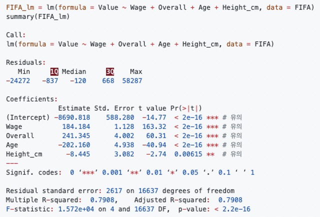

# 3. 비정형 데이터마이닝 (사용 데이터 : "영화 review")

```
- 영화 기생충_review.txt (다음 영화 리뷰데이터)
- 영화 기생충_사전.txt (출연진/캐릭터/감독 이름데이터)
```

### Q1) ‘영화 기생충_review.txt’ 데이터를 읽어온 뒤 숫자, 특수 문자 등을

### 제거하는 전처리 작업을 시행하시오.

### 그리고 ‘영화 기생충_review.txt’을 사전에 등록하라.

```
- 3.1.1) ‘영화 기생충_review.txt’, 숫자, 특수문자 제거
- 3.1.2) ‘영화 기생충_review.txt’, 사전에 등록
```

```python
# text, 모의고사 1-3
import konlpy  # !pip install konlpy
import re
from konlpy.tag import Komoran  # No JVM shared 에러 -> https://www.azul.com/downloads
from sklearn.feature_extraction.text import CountVectorizer # text 인스턴스 생성

# WordCloud 모의고사 1-3
from wordcloud import WordCloud # !pip install wordcloud
from collections import Counter # 단어 Count
import nltk
from nltk.corpus import stopwords
```

### 3.1.1) ‘영화 기생충_review.txt’, 숫자, 특수문자 제거

```python
file = open('./dataset/영화 기생충_review.txt', 'r', encoding='cp949')
print(type(file))
file
```

```
<class '_io.TextIOWrapper'>
```

```
<_io.TextIOWrapper name='./dataset/영화 기생충_review.txt' mode='r' encoding='cp949'>
```

```python
line = file.read()
print(type(line))
print(len(line))
line[:200]
```

```
<class 'str'>
54157
```

```
'별1개  준 사람들은   나베당임\n역쉬\n영화가 끝나고 가슴이 먹먹하고 답답햇습니다 너무나 충격적이었습니다..\n지금까지 나온 감독의 모든 작품이 압축되어있다는 느낌을 받음.  Bomb!!!\n대단한 영화. 몰입력 장난아님. 후아\n그닥\n칸하고 안맞나봄.\n봉준호식의 코메디와 사회비판 페이소스\n좋았습니다\n군더더기 없이 깔끔한 영화, 지금도 영화가 주는 메세지를 생각'
```

```python
line = line.split('\n')
print(type(line))
print(len(line))
line[:10]
```

```
<class 'list'>
1791
```

```
['별1개  준 사람들은   나베당임',
 '역쉬',
 '영화가 끝나고 가슴이 먹먹하고 답답햇습니다 너무나 충격적이었습니다..',
 '지금까지 나온 감독의 모든 작품이 압축되어있다는 느낌을 받음.  Bomb!!!',
 '대단한 영화. 몰입력 장난아님. 후아',
 '그닥',
 '칸하고 안맞나봄.',
 '봉준호식의 코메디와 사회비판 페이소스',
 '좋았습니다',
 '군더더기 없이 깔끔한 영화, 지금도 영화가 주는 메세지를 생각하는 중입니다']
```

```python
text = pd.Series(line)
print(type(text))
print(text.shape)
text[:10]
```

```
<class 'pandas.core.series.Series'>
(1791,)
```

```
0                             별1개  준 사람들은   나베당임
1                                             역쉬
2         영화가 끝나고 가슴이 먹먹하고 답답햇습니다 너무나 충격적이었습니다..
3    지금까지 나온 감독의 모든 작품이 압축되어있다는 느낌을 받음.  Bomb!!!
4                           대단한 영화. 몰입력 장난아님. 후아
5                                             그닥
6                                      칸하고 안맞나봄.
7                           봉준호식의 코메디와 사회비판 페이소스
8                                          좋았습니다
9      군더더기 없이 깔끔한 영화, 지금도 영화가 주는 메세지를 생각하는 중입니다
dtype: object
```

```python
# re.sub(find, replace, data) 패턴문자대체
# https://jdh5202.tistory.com/394
text = text.map(lambda x: re.sub(r"\d", " ", x))  # r"\d", r은 \d를 문자 그대로 인식
text = text.map(lambda x: re.sub("!!", " ", x))  # r"\d", r은 \d를 문자 그대로 인식
movie_clean = text.map(lambda x: re.sub('[-=+,#/\?:^$.@*\"※~&%ㆍ!』\\‘|\(\)\[\]\<\>`\'…》;]', ' ', x))
movie_clean[:10]
```

```
0                            별 개  준 사람들은   나베당임
1                                            역쉬
2        영화가 끝나고 가슴이 먹먹하고 답답햇습니다 너무나 충격적이었습니다
3    지금까지 나온 감독의 모든 작품이 압축되어있다는 느낌을 받음   Bomb
4                          대단한 영화  몰입력 장난아님  후아
5                                            그닥
6                                     칸하고 안맞나봄
7                          봉준호식의 코메디와 사회비판 페이소스
8                                         좋았습니다
9     군더더기 없이 깔끔한 영화  지금도 영화가 주는 메세지를 생각하는 중입니다
dtype: object
```

### 3.1.2) ‘영화 기생충_review.txt’, 사전에 등록

### Q2) 영화 기생충_사전.txt를 단어 사전으로 하는 TDM을 구축하고 빈도를 파악하고 시각화하시오

```python
# sep:구분자(\t:tab), names:컬럼명, cp949(Windows에서 많이 사용)
dicts = pd.read_csv('./dataset/영화 기생충_사전.txt', sep = '\t', encoding = 'cp949', names = ['word'])
print(type(dicts))
dicts
```

```
<class 'pandas.core.frame.DataFrame'>
```

|  | word |
| --- | --- |
| 0 | 기생충 |
| 1 | 봉준호 |
| 2 | 송강호 |
| 3 | 기택 |
| 4 | 이선균 |
| 5 | 박사장 |
| 6 | 조여정 |
| 7 | 연교 |
| 8 | 최우식 |
| 9 | 기우 |
| 10 | 박소담 |
| 11 | 기정 |
| 12 | 장혜진 |
| 13 | 충숙 |
| 14 | 이정은 |
| 15 | 이지혜 |
| 16 | 박서준 |

tm을 사용하기 위해서는 CountVectorizer()함수의 사용이 필요하다.  
따라서 이를 먼저 시행한 후에 cv_matrix을 이용하여 TDM을 구축해야한다.

```python
cv = CountVectorizer() # 텍스트에서 단어 출현횟수를 카운팅한 벡터
cv.fit(dicts['word'])  # 사전으로 fitbuf
```

```
CountVectorizer(analyzer='word', binary=False, decode_error='strict',
                dtype=<class 'numpy.int64'>, encoding='utf-8', input='content',
                lowercase=True, max_df=1.0, max_features=None, min_df=1,
                ngram_range=(1, 1), preprocessor=None, stop_words=None,
                strip_accents=None, token_pattern='(?u)\\b\\w\\w+\\b',
                tokenizer=None, vocabulary=None)
```

```python
# 문서로 tdm 생성
cv_matrix = cv.transform(text) # Series -> 매트릭스로 변경
print(type(cv_matrix))
cv_matrix
```

```
<class 'scipy.sparse.csr.csr_matrix'>
```

```
<1791x17 sparse matrix of type '<class 'numpy.int64'>'
	with 155 stored elements in Compressed Sparse Row format>
```

```python
name = cv.get_feature_names()  # 단어목록 확인
name
```

```
['기생충',
 '기우',
 '기정',
 '기택',
 '박사장',
 '박서준',
 '박소담',
 '봉준호',
 '송강호',
 '연교',
 '이선균',
 '이정은',
 '이지혜',
 '장혜진',
 '조여정',
 '최우식',
 '충숙']
```

```python
cv_mat = cv_matrix.toarray()
print(type(cv_mat))
print(cv_mat.shape)
cv_mat
```

```
<class 'numpy.ndarray'>
(1791, 17)
```

```
array([[0, 0, 0, ..., 0, 0, 0],
       [0, 0, 0, ..., 0, 0, 0],
       [0, 0, 0, ..., 0, 0, 0],
       ...,
       [0, 0, 0, ..., 0, 0, 0],
       [0, 0, 0, ..., 0, 0, 0],
       [0, 0, 0, ..., 0, 0, 0]])
```

```python
tdm = pd.DataFrame(cv_mat, columns = name)
tdm
```

|  | 기생충 | 기우 | 기정 | 기택 | 박사장 | 박서준 | 박소담 | 봉준호 | 송강호 | 연교 | 이선균 | 이정은 | 이지혜 | 장혜진 | 조여정 | 최우식 | 충숙 |
| --- | --- | --- | --- | --- | --- | --- | --- | --- | --- | --- | --- | --- | --- | --- | --- | --- | --- |
| 0 | 0 | 0 | 0 | 0 | 0 | 0 | 0 | 0 | 0 | 0 | 0 | 0 | 0 | 0 | 0 | 0 | 0 |
| 1 | 0 | 0 | 0 | 0 | 0 | 0 | 0 | 0 | 0 | 0 | 0 | 0 | 0 | 0 | 0 | 0 | 0 |
| 2 | 0 | 0 | 0 | 0 | 0 | 0 | 0 | 0 | 0 | 0 | 0 | 0 | 0 | 0 | 0 | 0 | 0 |
| 3 | 0 | 0 | 0 | 0 | 0 | 0 | 0 | 0 | 0 | 0 | 0 | 0 | 0 | 0 | 0 | 0 | 0 |
| 4 | 0 | 0 | 0 | 0 | 0 | 0 | 0 | 0 | 0 | 0 | 0 | 0 | 0 | 0 | 0 | 0 | 0 |
| ... | ... | ... | ... | ... | ... | ... | ... | ... | ... | ... | ... | ... | ... | ... | ... | ... | ... |
| 1786 | 0 | 0 | 0 | 0 | 0 | 0 | 0 | 0 | 0 | 0 | 0 | 0 | 0 | 0 | 0 | 0 | 0 |
| 1787 | 0 | 0 | 0 | 0 | 0 | 0 | 0 | 0 | 0 | 0 | 0 | 0 | 0 | 0 | 0 | 0 | 0 |
| 1788 | 0 | 0 | 0 | 0 | 0 | 0 | 0 | 0 | 0 | 0 | 0 | 0 | 0 | 0 | 0 | 0 | 0 |
| 1789 | 0 | 0 | 0 | 0 | 0 | 0 | 0 | 0 | 0 | 0 | 0 | 0 | 0 | 0 | 0 | 0 | 0 |
| 1790 | 0 | 0 | 0 | 0 | 0 | 0 | 0 | 0 | 0 | 0 | 0 | 0 | 0 | 0 | 0 | 0 | 0 |

1791 rows × 17 columns

```python
# 빈도 계산
tdm_freq = tdm.sum(axis=0).sort_values(ascending=False)  #axis=0 열, axis=1 행
tdm_freq
```

```
봉준호    79
송강호    31
기생충    21
이선균    10
조여정    10
최우식     4
이정은     3
박소담     2
장혜진     1
박사장     1
기정      1
이지혜     0
연교      0
박서준     0
기택      0
기우      0
충숙      0
dtype: int64
```

cv패키지의 transform과 get_feature_names()함수를 활용해 전처리를 하고  
tdm dataframe에 저장했다.  
단어별 빈도를 내림차순으로 정렬하여 tdm_freq에 저장하고 단어 빈도를 체크했다.

이후 단어 빈도를 바탕으로 막대그래프를 작성한다.

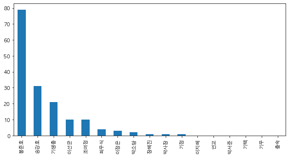

```python
# 시각화
tdm_freq.plot(kind = 'bar', figsize=(10,5))
plt.show()
```

barplot을 그린 결과 봉준호 감독에 대한 언급이 가장 많았고 그 다음 송강호, 기생충, 이선균 순이었다.

```python
komoran = Komoran(userdic='bugs.txt')
komoran
```

```
<konlpy.tag._komoran.Komoran at 0x1383693d0>
```

```python
string = ' '.join(text)
print(type(string))
print(len(string))
string[:200]
```

```
<class 'str'>
54068
```

```
'별 개  준 사람들은   나베당임 역쉬 영화가 끝나고 가슴이 먹먹하고 답답햇습니다 너무나 충격적이었습니다.. 지금까지 나온 감독의 모든 작품이 압축되어있다는 느낌을 받음.  Bomb ! 대단한 영화. 몰입력 장난아님. 후아 그닥 칸하고 안맞나봄. 봉준호식의 코메디와 사회비판 페이소스 좋았습니다 군더더기 없이 깔끔한 영화, 지금도 영화가 주는 메세지를 생각하'
```

```python
nouns = komoran.nouns(string) # string -> split noun
print(type(nouns))
print(len(nouns))
nouns[:10]
```

```
<class 'list'>
7912
```

```
['개', '사람', '베', '역', '영화', '가슴', '충격', '지금', '감독', '작품']
```

```python
cnt = Counter(nouns)
print(type(cnt))
print(len(cnt))
# cnt  # 로그 길어서 생략함 (아래 그림참조)
```

```
<class 'collections.Counter'>
2059
```

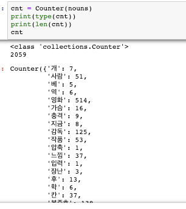

```python
df_freq10 = pd.DataFrame(columns = ['명사', '빈도'])
freq_list = cnt.most_common(10)
freq_list
```

```
[('영화', 514),
 ('봉준호', 138),
 ('감독', 125),
 ('것', 124),
 ('생각', 120),
 ('기대', 82),
 ('수', 82),
 ('기생충', 78),
 ('연기', 68),
 ('현실', 61)]
```

```python
for i,freq in enumerate(freq_list):
    df_freq10.loc[i] = freq
df_freq10
```

|  | 명사 | 빈도 |
| --- | --- | --- |
| 0 | 영화 | 514 |
| 1 | 봉준호 | 138 |
| 2 | 감독 | 125 |
| 3 | 것 | 124 |
| 4 | 생각 | 120 |
| 5 | 기대 | 82 |
| 6 | 수 | 82 |
| 7 | 기생충 | 78 |
| 8 | 연기 | 68 |
| 9 | 현실 | 61 |

```python
words_buf = dict(cnt.most_common(30))
words_buf
```

```
{'영화': 514,
 '봉준호': 138,
 '감독': 125,
 '것': 124,
 '생각': 120,
 '기대': 82,
 '수': 82,
 '기생충': 78,
 '연기': 68,
 '현실': 61,
 '송강호': 60,
 '봉': 60,
 '배우': 54,
 '작품': 53,
 '사람': 51,
 '거': 50,
 '최고': 48,
 '장면': 47,
 '상': 46,
 '듯': 45,
 '황금종려상': 41,
 '점': 40,
 '불편': 39,
 '만': 38,
 '안': 38,
 '느낌': 37,
 '칸': 37,
 '시간': 37,
 '번': 36,
 '스토리': 35}
```

```python
# 2글자 이상만 추출
words = words_buf.copy()
for key in words_buf.keys():
    if len(key)==1:
        del(words[key])
words
```

```
{'영화': 514,
 '봉준호': 138,
 '감독': 125,
 '생각': 120,
 '기대': 82,
 '기생충': 78,
 '연기': 68,
 '현실': 61,
 '송강호': 60,
 '배우': 54,
 '작품': 53,
 '사람': 51,
 '최고': 48,
 '장면': 47,
 '황금종려상': 41,
 '불편': 39,
 '느낌': 37,
 '시간': 37,
 '스토리': 35}
```

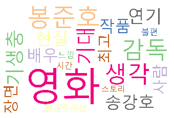

```python
wordcloud = WordCloud(font_path = "./korean.ttf", background_color='white',colormap = "Accent_r",
                      width=1500, height=1000).generate_from_frequencies(words)

plt.imshow(wordcloud)
plt.axis('off')
plt.show()
```

봉준호 감독에 대한 명사 등 영화 전체적인 관심이 동시에 감독에 대한 관심으로 표현되고  
있음을 알 수 있으나, 불편과 같은 부정적인 감정에 대한 언급도 적지 않음을 알 수 있다.